# BioInfomatics Report - Assignment 3

Greg Farmer

2022-05-22

### Intro

Source code: https://github.com/GregFarm/BioInformatics-Report-3-/blob/main/BioInfo%20Report.Rmd

This assignment is to assess our proficiency of using Rstudio and the r-coding language. With use of growth data, gene expression data and comparing the coding sequences of two bacteria, this report was constructed to show an understanding of some of the most useful aspects of Rstudio and how it can be applied in bioinformatics. All fo the coding sequences are left in for the clarity of the assessor.

Before knitting the Rmarkdown, please ensure that the correct libraries are loading in. The libraries needed are seqinr, kableExtra, R.utils. A detailed explanation of all the chunks is giving in the ‘Read Me’ file, but through the report a brief explanation of the code is given directly after the question heading and after the output the results are explained and any assignment questions are answered.

# Assignement Part 1 - Gene Expression

### Questions 1 - Read in the gene_expression.cvs file and show the values of the first six row

Simply, the table was read in, using `read.table`. The number of rows was specified, the `head` function could have been used too.

```r
URL = "https://raw.githubusercontent.com/markziemann/SLE712_files/master/assessment_task3/bioinfo_asst3_part1_files/gene_expression.tsv"
gene_exp <- read.table(URL, stringsAsFactors = FALSE, header = TRUE)
gene_exp[1:6,]
```

```
##                Name_Description GTEX.1117F.0226.SM.5GZZ7
## 1     ENSG00000223972.5_DDX11L1                        0
## 2      ENSG00000227232.5_WASH7P                      187
## 3   ENSG00000278267.1_MIR6859-1                        0
## 4 ENSG00000243485.5_MIR1302-2HG                        1
## 5     ENSG00000237613.2_FAM138A                        0
## 6      ENSG00000268020.3_OR4G4P                        0
##   GTEX.1117F.0426.SM.5EGHI GTEX.1117F.0526.SM.5EGHJ
## 1                        0                        0
## 2                      109                      143
## 3                        0                        1
## 4                        0                        0
## 5                        0                        0
## 6                        1                        0
```

### Questions 2 - Make a new column which is the mean of the other columns. Show a table of values for the first six genes

The desired columns were isolated in the data set and diveded my three to find the mean. Those mean values were stored in a now column in the gene_exp data frame.

```r
gene_mean <- (gene_exp$GTEX.1117F.0226.SM.5GZZ7 + gene_exp$GTEX.1117F.0426.SM.5EGHI + gene_exp$GTEX.1117F.0526.SM.5EGHJ)/3
gene_exp['Mean'] <- signif(gene_mean, digits = 6)
gene_exp[1:6,]
```

```
##                Name_Description GTEX.1117F.0226.SM.5GZZ7
## 1     ENSG00000223972.5_DDX11L1                        0
## 2      ENSG00000227232.5_WASH7P                      187
## 3   ENSG00000278267.1_MIR6859-1                        0
## 4 ENSG00000243485.5_MIR1302-2HG                        1
## 5     ENSG00000237613.2_FAM138A                        0
## 6      ENSG00000268020.3_OR4G4P                        0
##   GTEX.1117F.0426.SM.5EGHI GTEX.1117F.0526.SM.5EGHJ       Mean
## 1                        0                        0   0.000000
## 2                      109                      143 146.333000
## 3                        0                        1   0.333333
## 4                        0                        0   0.333333
## 5                        0                        0   0.000000
## 6                        1                        0   0.333333
```

### Questions 3 - List the 10 genes with the highest mean expression

The gene_exp data frame was ordered from highest to lowest mean and the top ten results are shown.

```r
high_mean <- gene_exp[order(-gene_exp$Mean),]
high_mean[1:10,]
```

```
##                Name_Description GTEX.1117F.0226.SM.5GZZ7
## 56179  ENSG00000198804.2_MT-CO1                   267250
## 56191  ENSG00000198886.2_MT-ND4                   273188
## 56186  ENSG00000198938.2_MT-CO3                   250277
## 56169  ENSG00000198888.2_MT-ND1                   243853
## 56185 ENSG00000198899.2_MT-ATP6                   141374
## 56198  ENSG00000198727.2_MT-CYB                   127194
## 56173  ENSG00000198763.3_MT-ND2                   159303
## 16618   ENSG00000211445.11_GPX3                   464959
## 56182  ENSG00000198712.1_MT-CO2                   128858
## 18688 ENSG00000156508.17_EEF1A1                   317642
##       GTEX.1117F.0426.SM.5EGHI GTEX.1117F.0526.SM.5EGHJ   Mean
## 56179                  1101779                   218923 529317
## 56191                   991891                   277628 514236
## 56186                  1041376                   223178 504944
## 56169                   772966                   194032 403617
## 56185                   696715                   151166 329752
## 56198                   638209                   141359 302254
## 56173                   543786                   149564 284218
## 16618                    39396                   306070 270142
## 56182                   545360                   122816 265678
## 18688                    39573                   339347 232187
```

### Questions 4 - Determine the number of genes with a mean <10

```r
true_sum <- gene_exp$Mean < 10
sum(true_sum, na.rm = TRUE)
```

```
## [1] 35988
```

### Questions 5 - Make a histogram plot of the mean values and include it into your report.

A histagram of the Mean vaules was constructed.

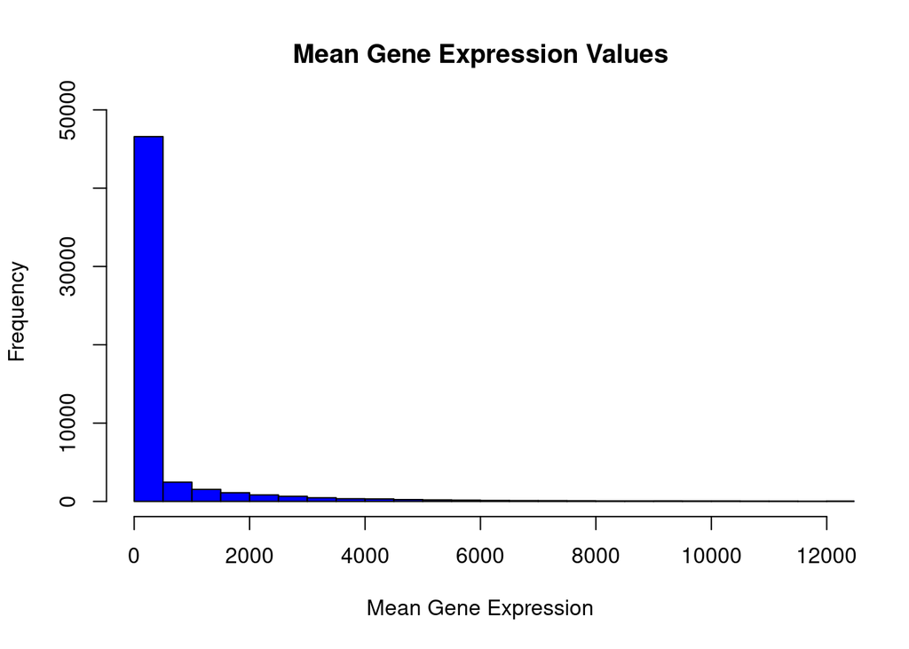

```r
x_vals <- gene_exp$Mean
h <-hist(x_vals,main="Mean Gene Expression Values", xlab="Mean Gene Expression",breaks= "scott" ,xlim=c(0,12000),ylim = c(0,48500), col = "blue")
```

### Questions 6 - Import this csv file into an R object. What are the column names?

Gene Expression cvs was read into Rstudio and the function `colnames` returned the names of the columns of the data frame.

```r
URL2 <- "https://raw.githubusercontent.com/markziemann/SLE712_files/master/assessment_task3/bioinfo_asst3_part1_files/growth_data.csv"
grow_data <- read.csv(URL2)
colnames(grow_data)
```

```
## [1] "Site"            "TreeID"          "Circumf_2005_cm" "Circumf_2010_cm"
## [5] "Circumf_2015_cm" "Circumf_2020_cm"
```

Simply using the `colnames` function to return the column names, being:

Site

TreeID

Circumf_2005_cm

Circumf_2010_cm

Circumf_2015_cm

Circumf_2020_cm

### Questions 7 - Calculate the mean and standard deviation of tree circumference at the start and end of the study at both sites.

The expression data was sorted my location using the `grep`function. The means and standard deviation of each of the lacations and timeframes is shown. `cat(paste` function is used to make the outputs more readable.

```r
#grep is used to isolate the required data
#northeast data
NE_data <-grow_data[grep("northeast", grow_data$Site),]
NE_mean05 <- mean(NE_data$Circumf_2005_cm, na.rm = TRUE)
NE_SD05 <- sd(NE_data$Circumf_2005_cm, na.rm = TRUE)
NE_mean20 <- mean(NE_data$Circumf_2020_cm, na.rm = TRUE)
NE_SD20 <- sd(NE_data$Circumf_2020_cm, na.rm = TRUE)
cat(paste("NorthEast 2005 mean =", NE_mean05), sep="\n")
```

```
## NorthEast 2005 mean = 5.292
```

```r
cat(paste("NorthEast 2005 standard deviation =", signif(NE_SD05,digits = 3)), sep="\n")
```

```
## NorthEast 2005 standard deviation = 0.914
```

```r
cat(paste("NorthEast 2020 mean =", NE_mean20), sep="\n")
```

```
## NorthEast 2020 mean = 54.228
```

```r
cat(paste("NorthEast 2020 standard deviation =", signif(NE_SD20,digits = 3)), sep="\n")
```

```
## NorthEast 2020 standard deviation = 25.2
```

```r
#southwest data
SW_data <-grow_data[grep("southwest", grow_data$Site),]
SW_mean05 <- mean(SW_data$Circumf_2005_cm, na.rm = TRUE)
SW_SD05 <- sd(SW_data$Circumf_2005_cm, na.rm = TRUE)
SW_mean20 <- mean(SW_data$Circumf_2020_cm, na.rm = TRUE)
SW_SD20 <- sd(SW_data$Circumf_2020_cm, na.rm = TRUE)
cat(paste("SouthWest 2005 mean =", SW_mean05), sep="\n")
```

```
## SouthWest 2005 mean = 4.862
```

```r
cat(paste("SouthWest 2005 standard deviation =", signif(SW_SD05,digits = 3)), sep="\n")
```

```
## SouthWest 2005 standard deviation = 1.15
```

```r
cat(paste("SouthWest 2020 mean =", SW_mean20), sep="\n")
```

```
## SouthWest 2020 mean = 45.596
```

```r
cat(paste("SouthWest 2020 standard deviation =", signif(SW_SD20,digits = 3)), sep="\n")
```

```
## SouthWest 2020 standard deviation = 17.9
```

Above, the results are returned individually.

NorthEast 2005 mean = 5.292

NorthEast 2005 standard deviation = 0.914

NorthEast 2020 mean = 54.228

NorthEast 2020 standard deviation = 25.2

SouthWest 2005 mean = 4.862

SouthWest 2005 standard deviation = 1.15

SouthWest 2020 mean = 45.596

SouthWest 2020 standard deviation = 17.9

### Questions 8 - Make a box plot of tree circumference at the start and end of the study at both sites.

A box plot of both locations and time frames was constructed.

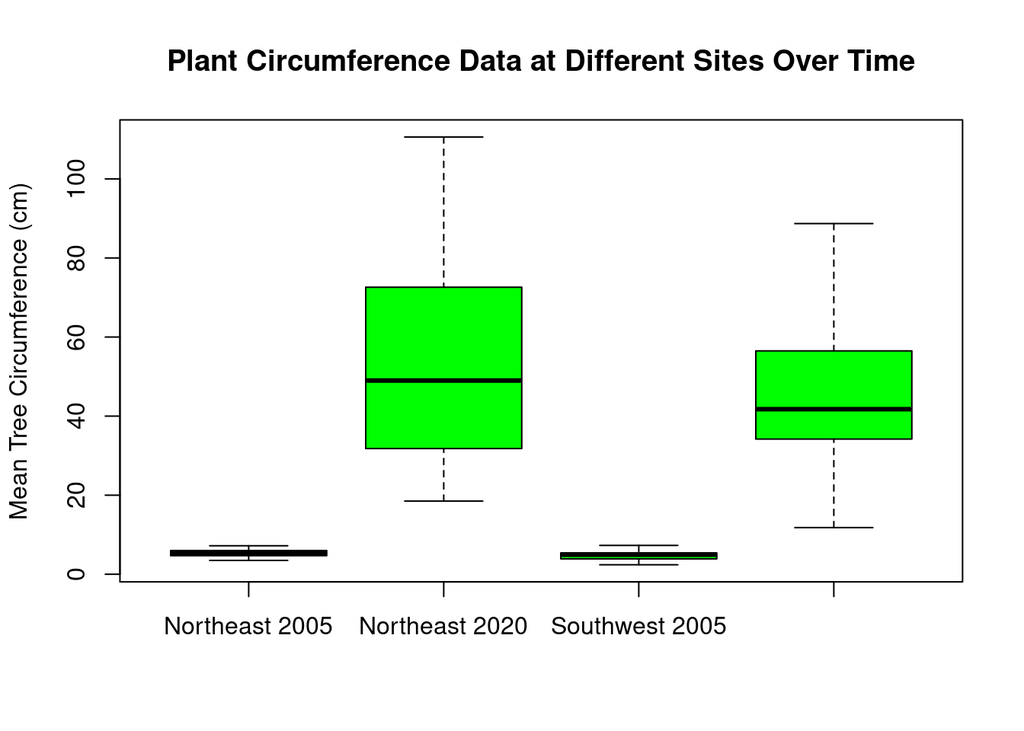

```r
boxplot(NE_data$Circumf_2005_cm, NE_data$Circumf_2020_cm,
        SW_data$Circumf_2005_cm, SW_data$Circumf_2020_cm,
        main ="Plant Circumference Data at Different Sites Over Time",
        names = c("Northeast 2005","Northeast 2020","Southwest 2005","Southwest 2020"),
        ylab = "Mean Tree Circumference (cm)",
        col = "green"
        )
```

### Questions 9 - Calculate the mean growth over the last 10 years at each site.

The date from the years 2010 - 2020 were isolated. The means of each column were found and added together and divded by three.

```r
NE_tenyear <-NE_data[,c("Circumf_2010_cm", "Circumf_2015_cm", "Circumf_2020_cm")]
NE_tenyear_mean <- colMeans(NE_tenyear, na.rm = TRUE)
sum(NE_tenyear_mean)/3
```

```
## [1] 30.01067
```

```r
SW_tenyear <-SW_data[,c("Circumf_2010_cm", "Circumf_2015_cm", "Circumf_2020_cm")]
SW_tenyear_mean <- colMeans(SW_tenyear, na.rm = TRUE)
sum(SW_tenyear_mean)/3
```

```
## [1] 25.67267
```

Above is the mean growth for each site over the last 10 years.

### Questions 10 - Use the t.test and wilcox.test functions to estimate the p-value that the 10 year growth is different at the two sites.

`t.test` and `wilcox.test` were used to find different p-values for the each site over the last ten years.

```r
ttest<- t.test(NE_tenyear, SW_tenyear)
ttest$p.value
```

```
## [1] 0.07787477
```

```r
NE_vec <- unlist(NE_tenyear)
SW_vec <- unlist(SW_tenyear)
wilcox <- wilcox.test(NE_vec, SW_vec)
wilcox
```

```
##
##  Wilcoxon rank sum test with continuity correction
##
## data:  NE_vec and SW_vec
## W = 12304, p-value = 0.1608
## alternative hypothesis: true location shift is not equal to 0
```

The p-values attained for the t-test and Wilcoxon tests were different, being 0.0779 and 0.161 respectively. Considering there aren’t any obvious outliners in the data, the t-test would be considered more accurate

# Assignement Part 2 - Examining biological sequence diversity

For this section the organisms being used are *Mycobacterium tuberculosis* (GCA_001318445) and *Escherichia coli* str. K-12 substr. MG1655 str. K12 (GCA_000005845)

### Questions 1.1 - Download the whole set of coding DNA sequences for E. coli and your organism of interest.

Both organisms FASTA files were read into Rstudio.

```r
URL_M <- "http://ftp.ensemblgenomes.org/pub/bacteria/release-53/fasta/bacteria_4_collection/mycobacterium_tuberculosis_gca_001318445/cds/Mycobacterium_tuberculosis_gca_001318445.6505_5_10.cds.all.fa.gz"
download.file(URL_M, destfile = "Mturb_cds.fa.gz")
URL_E="http://ftp.ensemblgenomes.org/pub/bacteria/release-53/fasta/bacteria_0_collection/escherichia_coli_str_k_12_substr_mg1655_gca_000005845/cds/Escherichia_coli_str_k_12_substr_mg1655_gca_000005845.ASM584v2.cds.all.fa.gz"
download.file(URL_E, destfile="ecoli_cds.fa.gz")

gunzip("Mturb_cds.fa.gz")
gunzip("ecoli_cds.fa.gz")

ecoli_cds <- seqinr::read.fasta("ecoli_cds.fa")
mturb_cds <- seqinr::read.fasta("Mturb_cds.fa")
```

### Question 1.2 - How many coding sequences are present in these organisms? How much coding DNA is there in total for these two organisms? Describe any differences between the two organisms.

The amount of coding sequences was found. `unzip` was used to to unpack the DNA info out of its coding sequences and the total amount was found.

```r
length(mturb_cds)
```

```
## [1] 4752
```

```r
length(ecoli_cds)
```

```
## [1] 4239
```

The total amount of coding sequences in *M. tuberculosis* is 4,752 and for *E. coli* the total amount of coding sequences is 4,239.

```r
m_len<-sapply(X = mturb_cds, FUN = length)
sum(m_len)
```

```
## [1] 3072513
```

```r
e_len<-sapply(X = ecoli_cds, FUN = length)
sum(e_len)
```

```
## [1] 3978528
```

*M. tuberculosis* has a total of 3,072,513 coding nucleotides.

*E. coli* has a total of 3,978,528 coding nucleotides.

*M. tuberculosis* has 513 more coding sequences, yet nearly 1 million less coding nucleotides compared to *E. coli*.

### Question 2.1 - Calculate the length of all coding sequences in these two organisms. Make a boxplot of coding sequence length in these organisms.

The lengths of all coding sequences was found above and those values were used to construct a boxplot

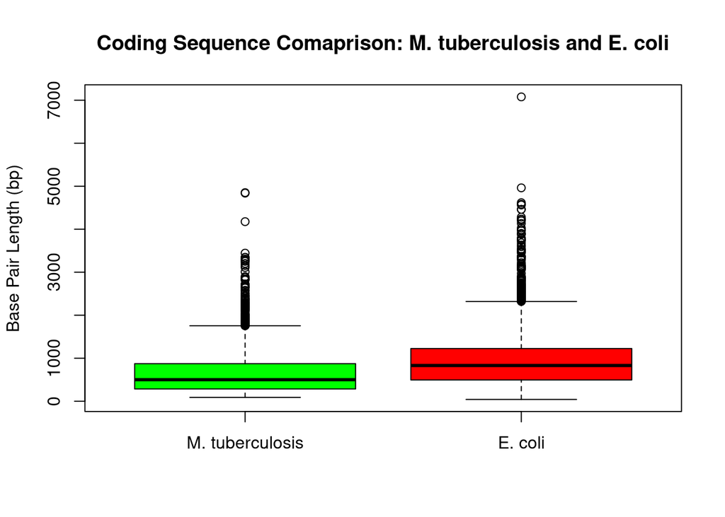

```r
boxplot(m_len, e_len, names = c("M. tuberculosis","E. coli"),
        main = "Coding Sequence Comaprison: M. tuberculosis and E. coli",
          ylab = "Base Pair Length (bp)",
        col = c("green","red"))
```

### Question 2.2 - What is the mean and median coding sequence length of these two organisms? Describe any differences between the two organisms

Simply used the `mean` and `median` to find the desired values.

```r
signif(mean(m_len), digits = 4)
```

```
## [1] 646.6
```

```r
median(m_len)
```

```
## [1] 501
```

```r
signif(mean(e_len), digits = 4)
```

```
## [1] 938.6
```

```r
median(e_len)
```

```
## [1] 831
```

The mean and median coding sequences length for *M. tuberculosis* was shown to be 647bp and 501bp respectively.

### Question 3.1 - Calculate the frequency of DNA bases in the total coding sequences for both organisms. Perform the same calculation for the total protein sequence.

The library seqinr allows for the total amount of each nucleotide to be found using the `count` function. The amino acid composition is able to be found using the `translate` funtion and applying it to the DNA sequences data.

```r
m_dna <- unlist(mturb_cds)
m_dna_comp <-seqinr::count(m_dna, wordsize = 1)
m_dna_comp
```

```
##
##       a       c       g       t
##  530813  985756 1012854  539899
```

```r
e_dna <- unlist(ecoli_cds)
e_dna_comp <-seqinr::count(e_dna, wordsize = 1)
e_dna_comp
```

```
##
##       a       c       g       t
##  955768  977594 1088501  956665
```

```r
m_prot <- lapply(mturb_cds, translate)
aa <- unique(m_prot[[2]])
aa <- aa[aa != "*"]
m_comp <- unlist(m_prot)
m_aa <- seqinr::count(m_comp, wordsize = 1 , alphabet = aa)

e_prot <- lapply(ecoli_cds, translate)
aa <- unique(m_prot[[2]])
aa <- aa[aa != "*"]
e_comp <- unlist(e_prot)
e_aa <- seqinr::count(e_comp, wordsize = 1 , alphabet = aa)
```

The output above shows first the *M. tuberculosis* DNA composition and then *E. coli*

### Question 3.2 -Create bar plots for nucleotide and amino acid frequency. Describe any differences between the two organisms.

A barplot is used to compare the nucleotide frequency of the two organsisms, the same is doen for the amino acids.

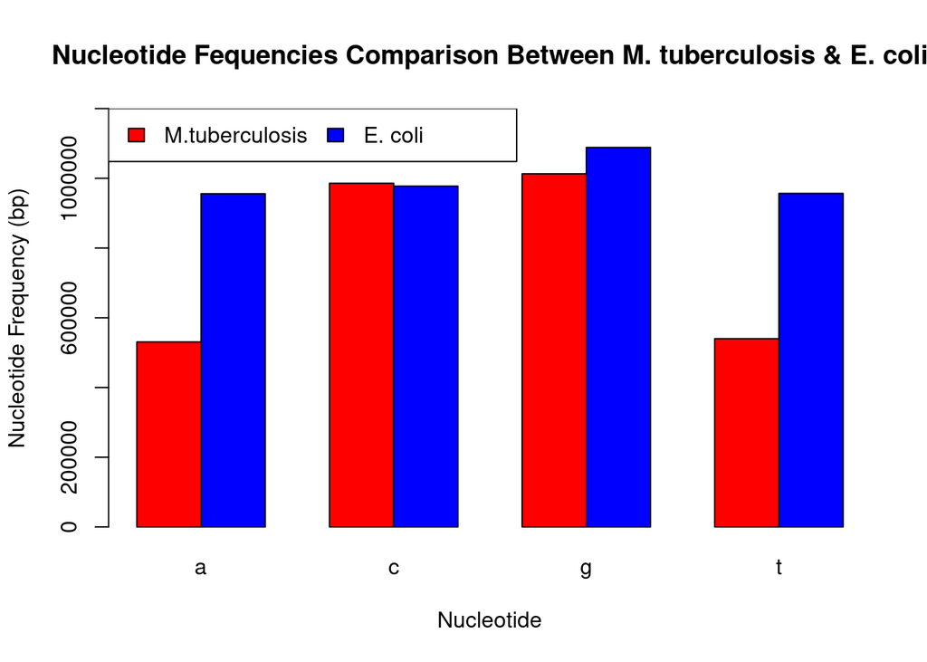

```r
#NT barplot

barplot(as.matrix(rbind(m_dna_comp, e_dna_comp)), beside = TRUE,
        names = c("a","c","g","t"), col = c("red","blue"),
        ylim = c(0,1200000),
        xlab = "Nucleotide", ylab = "Nucleotide Frequency (bp)",
        main = "Nucleotide Fequencies Comparison Between M. tuberculosis & E. coli")
legend("topleft", c("M.tuberculosis", "E. coli"), horiz = T, col = c("red", "blue"), fill = c("red", "blue"))
```

We know from questions 1 that *M. tuberculosis* have close to 1 million less base-pairs. Which can be seen in the graph above. *M. tuberculosis* has around after the amount of adenine and thymine when compared to *E. coli*.

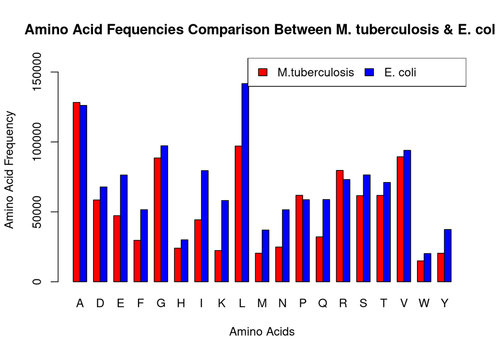

```r
#AA bar plot
barplot(as.matrix(rbind(m_aa, e_aa)), beside = TRUE, ylim = c(0,160000),
        col = c("red","blue"),
        xlab = "Amino Acids", ylab = "Amino Acid Frequency",
        main = "Amino Acid Fequencies Comparison Between M. tuberculosis & E. coli")
legend("topright", c("M.tuberculosis", "E. coli"), horiz = T, col = c("red", "blue"), fill = c("red", "blue"))
```

We can see in the graph above that on average *E. coli* contains more of each amino acid, except for Arganine, Proline and Alanine.

This would be expected due the *E. coli* have close to 1 million more nucleotides in the coding DNA.

### Question 4.1 -Create a codon usage table and quantify the codon usage bias among all coding sequences.

`uco` allows us to assess the coding usage bias in an organism and this was applied to both. The ten highest relative synonymous codon usage (RSCU) are shown for each organism. This ensures a massive table for each organism isn’t shown on the page.

```r
m_codon <- uco(m_dna, index="rscu", as.data.frame = TRUE)
head(m_codon[order(m_codon$RSCU, decreasing = TRUE),], n=10L)%>%
  kbl(caption = "M. tuberculosis Codon Usage: Top 10")%>%
  kable_styling(bootstrap_option = c("striped", "hover", "responsive", "condensed"), full_width = TRUE, fixed_thead=TRUE )
```

M. tuberculosis Codon Usage: Top 10

|  | AA | codon | eff | freq | RSCU |
| --- | --- | --- | --- | --- | --- |
| ctg | Leu | ctg | 47625 | 0.0465010 | 2.943176 |
| atc | Ile | atc | 34872 | 0.0340490 | 2.359830 |
| acc | Thr | acc | 35743 | 0.0348994 | 2.314099 |
| cgc | Arg | cgc | 30277 | 0.0295624 | 2.281040 |
| ccg | Pro | ccg | 33476 | 0.0326859 | 2.165085 |
| tcg | Ser | tcg | 21757 | 0.0212435 | 2.118638 |
| ggc | Gly | ggc | 43437 | 0.0424119 | 1.962168 |
| cgg | Arg | cgg | 25495 | 0.0248933 | 1.920769 |
| gtg | Val | gtg | 40923 | 0.0399572 | 1.831335 |
| gcc | Ala | gcc | 56562 | 0.0552271 | 1.763979 |

```r
e_codon <-uco(e_dna, index="rscu", as.data.frame = TRUE)
head(e_codon[order(e_codon$RSCU, decreasing = TRUE),], n=10L)%>%
  kbl(caption = "E coli Codon Usage: Top 10")%>%
  kable_styling(bootstrap_option = c("striped", "hover", "responsive", "condensed"), full_width = TRUE, fixed_thead=TRUE )
```

E coli Codon Usage: Top 10

|  | AA | codon | eff | freq | RSCU |
| --- | --- | --- | --- | --- | --- |
| ctg | Leu | ctg | 70714 | 0.0533217 | 2.993586 |
| cgc | Arg | cgc | 29441 | 0.0221999 | 2.416134 |
| cgt | Arg | cgt | 27979 | 0.0210975 | 2.296152 |
| ccg | Pro | ccg | 31074 | 0.0234313 | 2.117479 |
| taa | Stp | taa | 2726 | 0.0020555 | 1.929229 |
| acc | Thr | acc | 31139 | 0.0234803 | 1.753692 |
| agc | Ser | agc | 21291 | 0.0160544 | 1.671806 |
| ggc | Gly | ggc | 39536 | 0.0298120 | 1.626226 |
| aaa | Lys | aaa | 44592 | 0.0336245 | 1.534665 |
| att | Ile | att | 40501 | 0.0305397 | 1.528128 |

The first ten are shown to minimise the output. Interestingly, ctg (lucine) was by far the highest expressed codon. In E. coli, second and third were both codons that coded for arginine. Both organisms had a bias towards the cgc codon when coding for arginine

### Question 5.1 - In the organism of interest, identify 10 protein sequence k-mers of length 3-5 which are the most overand under-represented k-mers in your organism of interest.

`options(scipen=999)` stops the expression of small numbers in scientific notation. K-mer analysis was done for *M. tuberculosis* to determine the five highest and five lowest 3-mers, 4-mers and 5-mers in the amino acid sequences. Once found, a simple `grep` function was used to find the same k-mers in *E. coli* eg grep(“AAA”, rownames(e_freq3)). All those values were used to construct comparitive bar plots.

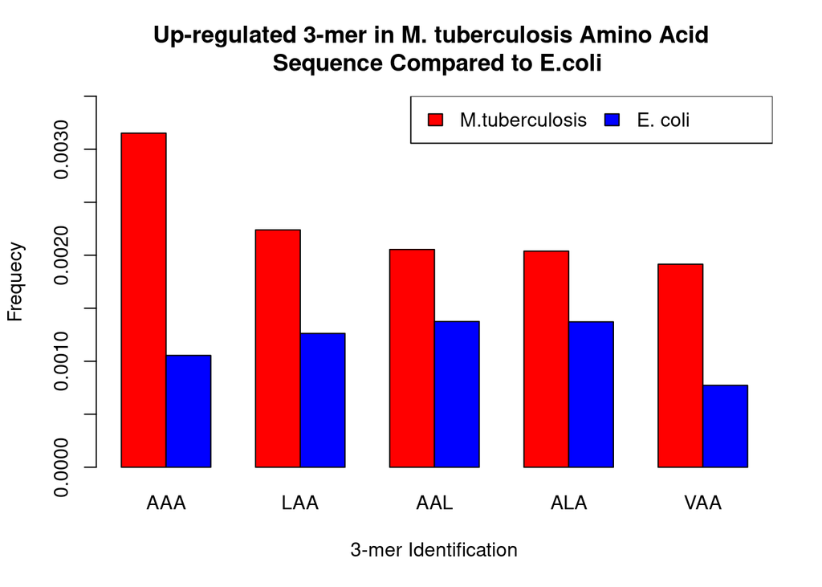

```r
options(scipen=999)
m_freq3 <- seqinr::count(m_comp,wordsize=3,alphabet=aa,freq=TRUE)
m_sorted_high3 <- head(sort(m_freq3, decreasing = TRUE),n=5L)
m_sorted_low3 <-head(sort(m_freq3, decreasing = FALSE),n=5L)
e_freq3 <- seqinr::count(e_comp,wordsize=3,alphabet=aa,freq=TRUE)
e_sorted_high3 <- e_freq3[c(1,2889,161,153,5777)]
e_sorted_low3<-e_freq3[c(6603, 6280, 6288, 6319, 6335)]

barplot(as.matrix(rbind(m_sorted_high3, e_sorted_high3)), beside = TRUE,
 ylim = c(0,0.0035),
 xlab = "3-mer Identification", ylab = "Frequecy",
 main = "Up-regulated 3-mer in M. tuberculosis Amino Acid
 Sequence Compared to E.coli",
 col = c("red","blue"))
legend("topright", c("M.tuberculosis", "E. coli"), horiz = T, col = c("red", "blue"), fill = c("red", "blue"))
```

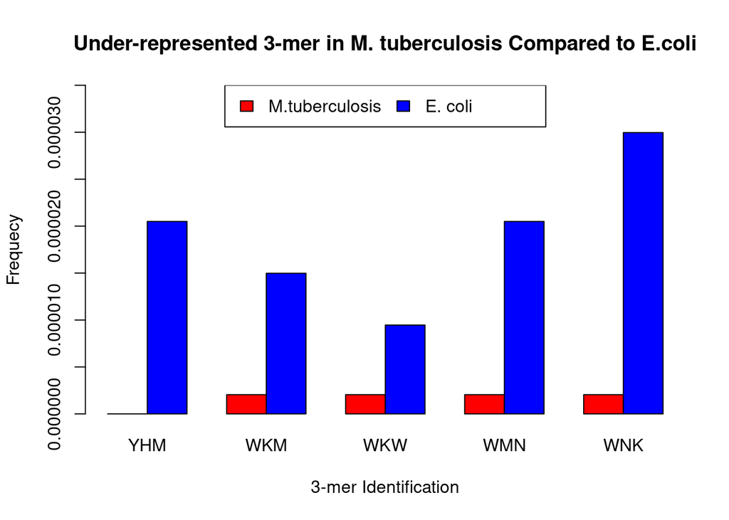

```r
barplot(as.matrix(rbind(m_sorted_low3, e_sorted_low3)), beside = TRUE, ylim = c(0, 0.000035),
        xlab = "3-mer Identification", ylab = "Frequecy",
        main = "Under-represented 3-mer in M. tuberculosis Compared to E.coli",
         col = c("red","blue"))
legend("top", c("M.tuberculosis", "E. coli"), horiz = T, col = c("red", "blue"), fill = c("red", "blue"))
```

```r
m_freq4 <-  seqinr::count(m_comp,wordsize=4,alphabet=aa,freq=TRUE)
m_sorted_high4 <- head(sort(m_freq4, decreasing = TRUE),n=5L)

e_freq4 <-  seqinr::count(e_comp,wordsize=4,alphabet=aa,freq=TRUE)
e_sorted_high4<-e_freq4[c(1, 2889, 153, 54873, 9)]


m_sorted_low4 <- head(sort(m_freq4, decreasing = FALSE),n=5L)


e_sorted_low4<-e_freq4[c(341, 475, 540, 569, 703)]
```

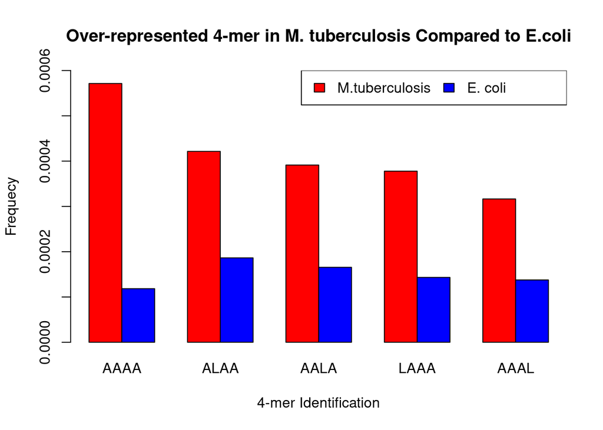

```r
barplot(as.matrix(rbind(m_sorted_high4, e_sorted_high4)), beside = TRUE, ylim = c(0, 0.0006),
        xlab = "4-mer Identification", ylab = "Frequecy",
        main = "Over-represented 4-mer in M. tuberculosis Compared to E.coli",
         col = c("red","blue"))
legend("topright", c("M.tuberculosis", "E. coli"), horiz = T, col = c("red", "blue"), fill = c("red", "blue"))
```

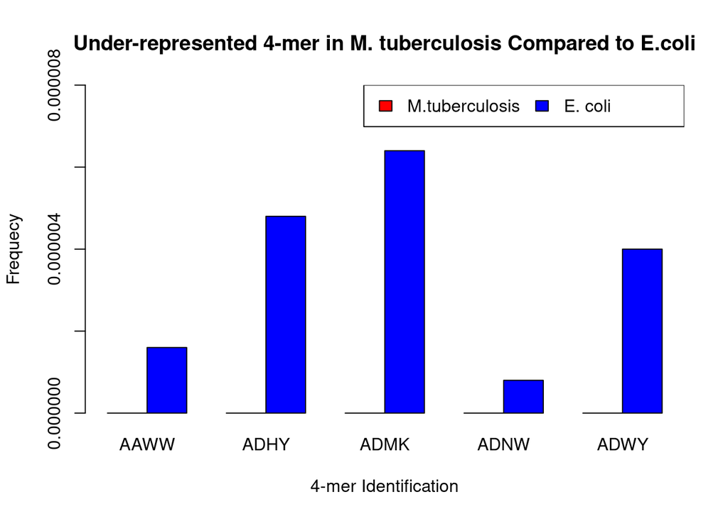

```r
barplot(as.matrix(rbind(m_sorted_low4, e_sorted_low4)), beside = TRUE, ylim = c(0, 0.000008),
        xlab = "4-mer Identification", ylab = "Frequecy",
        main = "Under-represented 4-mer in M. tuberculosis Compared to E.coli",
         col = c("red","blue"))
legend("topright", c("M.tuberculosis", "E. coli"), horiz = T, col = c("red", "blue"), fill = c("red", "blue"))
```

```r
m_freq5 <-  seqinr::count(m_comp,wordsize=5,alphabet=aa,freq=TRUE)
m_sorted_high5 <- head(sort(m_freq5, decreasing = TRUE),n=5L)

e_freq5 <-  seqinr::count(e_comp,wordsize=5,alphabet=aa,freq=TRUE)
e_sorted_high5<-e_freq5[c(1, 2889, 54873, 153, 5777)]

m_sorted_low5 <- head(sort(m_freq5, decreasing = FALSE),n=5L)

e_sorted_low5<-e_freq5[c(70, 73, 103, 132, 137)]
```

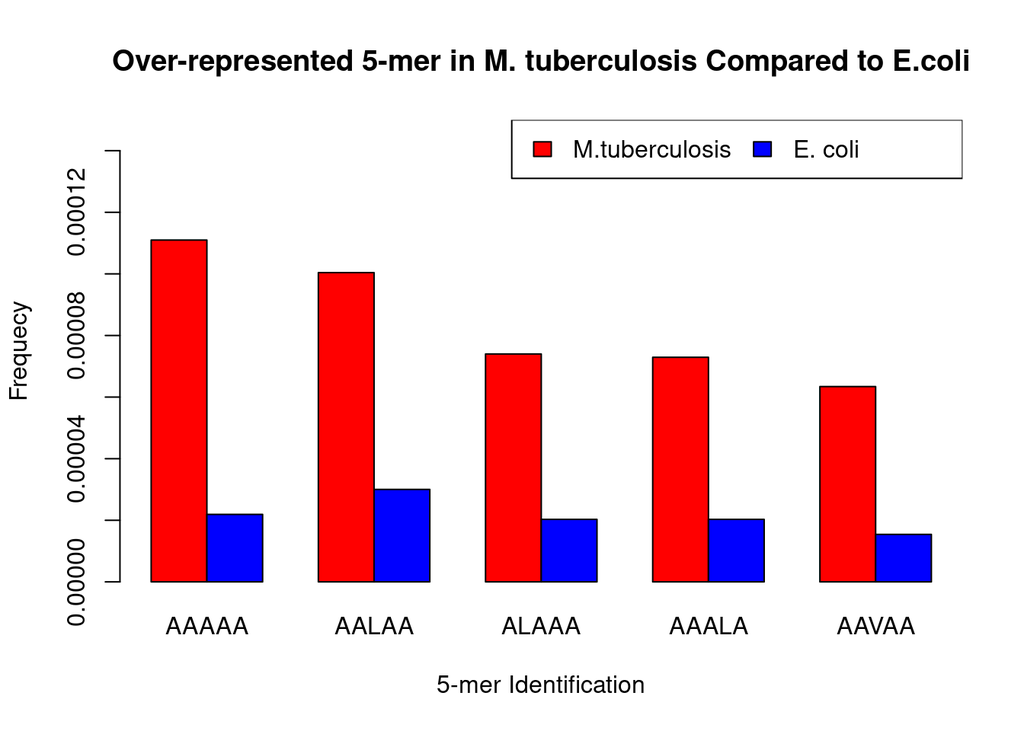

```r
barplot(as.matrix(rbind(m_sorted_high5, e_sorted_high5)), beside = TRUE, ylim = c(0, 0.00015),
        xlab = "5-mer Identification", ylab = "Frequecy",
        main = "Over-represented 5-mer in M. tuberculosis Compared to E.coli",
         col = c("red","blue"))
legend("topright", c("M.tuberculosis", "E. coli"), horiz = T, col = c("red", "blue"), fill = c("red", "blue"))
```

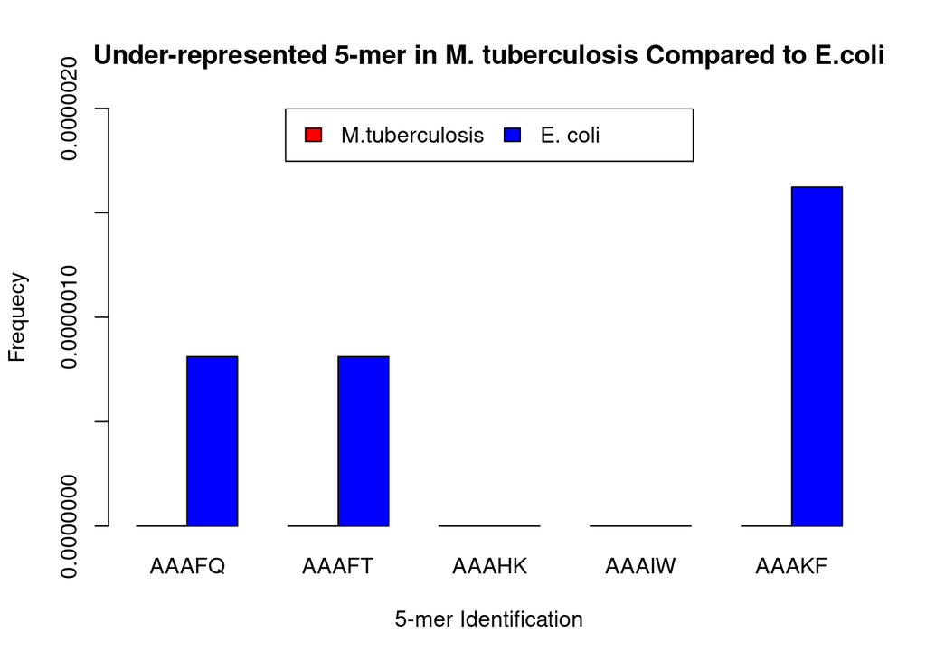

```r
barplot(as.matrix(rbind(m_sorted_low5, e_sorted_low5)), beside = TRUE, ylim = c(0, 0.000002),
        xlab = "5-mer Identification", ylab = "Frequecy",
        main = "Under-represented 5-mer in M. tuberculosis Compared to E.coli",
         col = c("red","blue"))
legend("top", c("M.tuberculosis", "E. coli"), horiz = T, col = c("red", "blue"), fill = c("red", "blue"))
```

Above are all the graphs showing different k-mer lengths and shows what being over and under expressed in *M. tuberculosis* compared to *E. coil*.

One of the most obvious differences is the over representation of high alanine k-mers in *M. tuberculosis* compared to *E. coil*. Furthermore, there are far more k-mers that aren’t represented at all in *M. tuberculosis* compared to *E. coil*. *M. tuberculosis* has a higher occurrence of k-mers that are mainly consisting of alanine than *E. coli*.Using the graphs shown above its easy to compare the over and under represented k-mer of *M. tuberculosis* compared to *E. coil*.